# Wine Sale Forecasting

2024-10-07

## 1 Load required Libraries

```r
library(openxlsx)
library(timetk)
library(dplyr)
library(lubridate)
library(recipes)
```

```r
library(rsample)
library(parsnip)
library(workflows)
library(forecastML)
library(corrplot)
library(doParallel)
library(timeDate)
library(astsa)
library(ggplot2)
library(forecast)
library(bsts)
library(nlme)
library(splines)
library(caret)
```

## 2 Set Parallel Processing

```r
# setting up parallel processing
registerDoSEQ()
cl = makePSOCKcluster(4)
registerDoParallel(cl)
```

## 3 Function for Performance Metrics

```r
Metrics.fun = function(x,y) {
  AE= abs(x-y)  # Absolute difference
  AE.mean = mean(AE)  # Mean AE
  SE = AE^2  # Squared AE
  MSE = mean(SE)  # Mean of squared error
  RMSE = sqrt(MSE) # Root of MSE
  RMSE.se = sd(SE) # Standard error of SE
  Metrics = data.frame(MAE = AE.mean,
                       RMSE=RMSE)
  Metrics
}
```

## 4 Load Dataset

```r
setwd("C:\\Users\\YCHEN\\Git\\Weather on wine sales")

load("Weekly wine sales data.RData")
str(ApothicUnit)
```

```
## 'data.frame':    312 obs. of  31 variables:
##  $ ID                : num  1 2 3 4 5 6 7 8 9 10 ...
##  $ AWND.sum          : num  58.8 73.4 68 58.6 82.5 ...
##  $ AWND.mean         : num  8.4 10.48 9.72 8.37 11.79 ...
##  $ AWND.max          : num  12.3 15 16.8 14.8 15.2 ...
##  $ AWND.min          : num  2.68 4.92 4.03 3.8 8.05 5.59 6.04 7.16 8.5 6.49 ...
##  $ SNOW.sum          : num  5.1 5.9 1 0 1.5 0.3 3.8 0.3 0 0 ...
##  $ SNOW.mean         : num  0.729 0.843 0.143 0 0.214 ...
##  $ SNOW.max          : num  4.7 5.4 0.6 0 1.5 0.3 3.5 0.3 0 0 ...
##  $ SNOW.min          : num  0 0 0 0 0 0 0 0 0 0 ...
##  $ SNWD.sum          : num  12 13 1 0 2 0 6 0 0 0 ...
##  $ SNWD.mean         : num  1.714 1.857 0.143 0 0.286 ...
##  $ SNWD.max          : num  4 5 1 0 1 0 3 0 0 0 ...
##  $ SNWD.min          : num  0 0 0 0 0 0 0 0 0 0 ...
##  $ PRCP.sum          : num  0.36 1.07 0.38 0 0.2 0.21 0.94 0.48 0.28 0.19 ...
```

[output cut: 17 more lines]

## 5 Exploratory Data Analysis (EDA)

```r
ApothicUnit %>%
  plot_time_series(DATE,apothicPremiumUnit,
                   .interactive=F,
                   .facet_scales="free",
                   .color_var=year(DATE),
                   .facet_ncol=2,
                   .x_lab="Date",
                   .y_lab="Apothic (Unit)")+
  labs(title = "Fig. 1 Weekly Wine Sales")
```

[figure not shown]

Note the uptrending of sales over the years.

```r
ApothicUnit %>%
  dplyr::group_by(Year) %>%
  plot_time_series(DATE,apothicPremiumUnit,
                   .interactive=F,
                   .facet_scales="free",
                   .facet_ncol=2,
                   .x_lab="Date",
                   .y_lab="Apothic (Unit)")+
  labs(title = "Fig. 2 Weekly Wine Sales by Year")
```

[figure not shown]

Monthly variation of sales is obvious.

```r
corrplot(cor(ApothicUnit[,c(2:8,10:16,18:25)]),
         method="square",order="hclust",
         title = "Fig. 3 Correlation Plot/Matrix of All Variables",
         mar = c(1,3,1,1))
```

[figure not shown]

Note the extremely high correlation among many related variables.

Select a subset of variables for prediction.

```r
ApothicUnit_df = ApothicUnit %>%
  dplyr::select(apothicPremiumUnit,PRCP.mean, TMIN.mean,AWND.mean,
                SNOW.mean,SNWD.mean,Year, Month, WeekOfYear,WeekNo)
names(ApothicUnit_df)
```

```
##  [1] "apothicPremiumUnit" "PRCP.mean"          "TMIN.mean"
##  [4] "AWND.mean"          "SNOW.mean"          "SNWD.mean"
##  [7] "Year"               "Month"              "WeekOfYear"
## [10] "WeekNo"
```

```r
corrplot(cor(ApothicUnit_df[,2:6]),method="number",order="hclust",
         title = "Fig. 4 Correlation Plot/Matrix of Selected Variables",
         mar = c(1,3,1,1))
```

[figure not shown]

Check NAs and zero variance or near-zero variance

```r
apply(is.na(ApothicUnit_df),2,sum)
```

```
## apothicPremiumUnit          PRCP.mean          TMIN.mean          AWND.mean
##                  0                  0                  0                  0
##          SNOW.mean          SNWD.mean               Year              Month
##                  0                  0                  0                  0
##         WeekOfYear             WeekNo
##                  0                  0
```

```r
nearZeroVar(ApothicUnit_df,names=T)
```

```
## character(0)
```

Plots of wine sales against weather variables

```r
ggplot(ApothicUnit_df,aes(x=PRCP.mean,y=apothicPremiumUnit))+
  geom_point()+
  geom_smooth(method="lm",se=F)+
  geom_smooth(method="loess",se=F,color="red")
```

[figure not shown]

```r
ggplot(ApothicUnit_df,aes(x=TMIN.mean,y=apothicPremiumUnit))+
  geom_point()+
  geom_smooth(method="lm",se=F)+
  geom_smooth(method="loess",se=F,color="red")
```

[figure not shown]

```r
ggplot(ApothicUnit_df,aes(x=AWND.mean,y=apothicPremiumUnit))+
  geom_point()+
  geom_smooth(method="lm",se=F)+
  geom_smooth(method="loess",se=F,color="red")
```

[figure not shown]

```r
ggplot(ApothicUnit_df,aes(x=SNOW.mean,y=apothicPremiumUnit))+
  geom_point()+
  geom_smooth(method="lm",se=F)+
  geom_smooth(method="loess",se=F,color="red")
```

[figure not shown]

```r
ggplot(ApothicUnit_df,aes(x=SNWD.mean,y=apothicPremiumUnit))+
  geom_point()+
  geom_smooth(method="lm",se=F)+
  geom_smooth(method="loess",se=F,color="red")
```

[figure not shown]

Check time series autocorrelation.

```r
lag2.plot(as.ts(ApothicUnit_df$apothicPremiumUnit),
          as.ts(ApothicUnit_df$PRCP.mean),
          max.lag=15)
```

[figure not shown]

```r
lag2.plot(as.ts(ApothicUnit_df$apothicPremiumUnit),
          as.ts(ApothicUnit_df$TMIN.mean),
          max.lag=15)
```

[figure not shown]

```r
lag2.plot(as.ts(ApothicUnit_df$apothicPremiumUnit),
          as.ts(ApothicUnit_df$AWND.mean),
          max.lag=15)
```

[figure not shown]

```r
lag2.plot(as.ts(ApothicUnit_df$apothicPremiumUnit),
          as.ts(ApothicUnit_df$SNOW.mean),
          max.lag=15)
```

[figure not shown]

```r
lag2.plot(as.ts(ApothicUnit_df$apothicPremiumUnit),
          as.ts(ApothicUnit_df$SNWD.mean),
          max.lag=15)
```

[figure not shown]

## 6 Create Dummy Holiday Variables

```r
ApothicUnit_df$week.end = seq(as.Date("2012-01-15"),as.Date("2017-12-31"),by="1 week")
ApothicUnit_df$week.start = ApothicUnit_df$week.end - 7
```

Christmas

```r
Christmas.Dates = timeDate::ChristmasDay(min(ApothicUnit_df$Year):max(ApothicUnit_df$Year))
for (i in 1:nrow(ApothicUnit_df)) {
  week = seq(ApothicUnit_df[i,]$week.start+1,ApothicUnit_df[i,]$week.end,length.out=7)
  ApothicUnit_df$Christmas[i] =  ifelse(length(base::intersect(week,as.Date(Christmas.Dates))) == 0,0,1)
}
```

Thanksgiving

```r
ThanksgivingDay.Dates = timeDate::USThanksgivingDay(min(ApothicUnit_df$Year):max(ApothicUnit_df$Year))
for (i in 1:nrow(ApothicUnit_df)) {
  week = seq(ApothicUnit_df[i,]$week.start+1,ApothicUnit_df[i,]$week.end,length.out=7)
  ApothicUnit_df$ThanksgivingDay[i] = ifelse(length(base::intersect(week,as.Date(ThanksgivingDay.Dates))) == 0,0,1)
}
```

New Year’s day

```r
NewYearsDay.Dates = timeDate::NewYearsDay(min(ApothicUnit_df$Year):max(ApothicUnit_df$Year))
for (i in 1:nrow(ApothicUnit_df)) {
  week = seq(ApothicUnit_df[i,]$week.start+1,ApothicUnit_df[i,]$week.end,length.out=7)
  ApothicUnit_df$NewYearsDay[i] = ifelse(length(base::intersect(week,as.Date(NewYearsDay.Dates))) == 0,0,1)
}
```

Independence day

```r
IndependenceDay.Dates = timeDate::USIndependenceDay(min(ApothicUnit_df$Year):max(ApothicUnit_df$Year))
for (i in 1:nrow(ApothicUnit_df)) {
  week = seq(ApothicUnit_df[i,]$week.start+1,ApothicUnit_df[i,]$week.end,length.out=7)
  ApothicUnit_df$IndependenceDay[i] = ifelse(length(base::intersect(week,as.Date(IndependenceDay.Dates))) == 0,0,1)
}
```

Labor day

```r
LaborDay.Dates = timeDate::USLaborDay(min(ApothicUnit_df$Year):max(ApothicUnit_df$Year))
for (i in 1:nrow(ApothicUnit_df)) {
  week = seq(ApothicUnit_df[i,]$week.start+1,ApothicUnit_df[i,]$week.end,length.out=7)
  ApothicUnit_df$LaborDay[i] = ifelse(length(base::intersect(week,as.Date(LaborDay.Dates))) == 0,0,1)
}
```

Memorial day

```r
MemorialDay.Dates = timeDate::USMemorialDay(min(ApothicUnit_df$Year):max(ApothicUnit_df$Year))
for (i in 1:nrow(ApothicUnit_df)) {
  week = seq(ApothicUnit_df[i,]$week.start+1,ApothicUnit_df[i,]$week.end,length.out=7)
  ApothicUnit_df$MemorialDay[i] = ifelse(length(base::intersect(week,as.Date(MemorialDay.Dates))) == 0,0,1)
}
```

Presidents day

```r
PresidentsDay.Dates = timeDate::USPresidentsDay(min(ApothicUnit_df$Year):max(ApothicUnit_df$Year))
for (i in 1:nrow(ApothicUnit_df)) {
  week = seq(ApothicUnit_df[i,]$week.start+1,ApothicUnit_df[i,]$week.end,length.out=7)
  ApothicUnit_df$PresidentsDay[i] = ifelse(length(base::intersect(week,as.Date(PresidentsDay.Dates))) == 0,0,1)
}
```

MLKing’S day

```r
MLKingsBirthday.Dates = timeDate::USMLKingsBirthday(min(ApothicUnit_df$Year):max(ApothicUnit_df$Year))
for (i in 1:nrow(ApothicUnit_df)) {
  week = seq(ApothicUnit_df[i,]$week.start+1,ApothicUnit_df[i,]$week.end,length.out=7)
  ApothicUnit_df$MLKingsBirthday[i] = ifelse(length(base::intersect(week,as.Date(MLKingsBirthday.Dates))) == 0,0,1)
}
```

Veterans day

```r
VeteransDay.Dates = timeDate::USVeteransDay(min(ApothicUnit_df$Year):max(ApothicUnit_df$Year))
for (i in 1:nrow(ApothicUnit_df)) {
  week = seq(ApothicUnit_df[i,]$week.start+1,ApothicUnit_df[i,]$week.end,length.out=7)
  ApothicUnit_df$VeteransDay[i] = ifelse(length(base::intersect(week,as.Date(VeteransDay.Dates))) == 0,0,1)
}
```

## 7 Train and Test Data Split

```r
ApothicUnit_train = ApothicUnit_df[1:(nrow(ApothicUnit_df)-40),]
ApothicUnit_test = ApothicUnit_df[(nrow(ApothicUnit_df)-40+1):nrow(ApothicUnit_df),]
names(ApothicUnit_train)
```

```
##  [1] "apothicPremiumUnit" "PRCP.mean"          "TMIN.mean"
##  [4] "AWND.mean"          "SNOW.mean"          "SNWD.mean"
##  [7] "Year"               "Month"              "WeekOfYear"
## [10] "WeekNo"             "week.end"           "week.start"
## [13] "Christmas"          "ThanksgivingDay"    "NewYearsDay"
## [16] "IndependenceDay"    "LaborDay"           "MemorialDay"
## [19] "PresidentsDay"      "MLKingsBirthday"    "VeteransDay"
```

```r
TS_Forecast_train_df = ApothicUnit_train %>%
  dplyr::select(1:6,11) %>%
  dplyr::rename("Apothic" = "apothicPremiumUnit")
str(TS_Forecast_train_df)
```

```
## 'data.frame':    272 obs. of  7 variables:
##  $ Apothic  : num  881 848 839 1081 1388 ...
##  $ PRCP.mean: num  0.0514 0.1529 0.0543 0 0.0286 ...
##  $ TMIN.mean: num  18 14.1 27.1 31.3 20.7 ...
##  $ AWND.mean: num  8.4 10.48 9.72 8.37 11.79 ...
##  $ SNOW.mean: num  0.729 0.843 0.143 0 0.214 ...
##  $ SNWD.mean: num  1.714 1.857 0.143 0 0.286 ...
##  $ week.end : Date, format: "2012-01-15" "2012-01-22" ...
```

```r
TS_Forecast_test_df = ApothicUnit_test %>%
  dplyr::select(1,11) %>%
  dplyr::rename("Apothic" = "apothicPremiumUnit")
str(TS_Forecast_test_df)
```

```
## 'data.frame':    40 obs. of  2 variables:
##  $ Apothic : num  4700 5649 6181 4071 4252 ...
##  $ week.end: Date, format: "2017-04-02" "2017-04-09" ...
```

## 8 Model Building and Testing

### 8.1 SARIMA models

logarithm transformation does not help too much.

```r
plot.ts(ts(TS_Forecast_train_df[,1]))
```

[figure not shown]

```r
acf2(ts(TS_Forecast_train_df[,1]))
```

[figure not shown]

```
##      [,1] [,2] [,3] [,4] [,5]  [,6] [,7] [,8]  [,9] [,10] [,11] [,12] [,13]
## ACF  0.88 0.81 0.80 0.78 0.75  0.72 0.72 0.71  0.67  0.66  0.67  0.64  0.60
## PACF 0.88 0.17 0.25 0.11 0.05 -0.02 0.12 0.03 -0.08  0.07  0.12 -0.09 -0.07
##      [,14] [,15] [,16] [,17] [,18] [,19] [,20] [,21] [,22] [,23] [,24] [,25]
## ACF   0.56  0.54  0.51  0.50  0.49  0.48  0.47  0.46  0.45  0.43  0.42  0.41
## PACF -0.10 -0.06 -0.04  0.08  0.01  0.04  0.05  0.02  0.03 -0.07  0.07 -0.01
##      [,26] [,27]
## ACF   0.39  0.38
## PACF -0.02  0.05
```

```r
plot.ts(log10(ts(TS_Forecast_train_df[,1])))  # seems better
```

[figure not shown]

```r
acf2(log10(ts(TS_Forecast_train_df[,1])))  # seems better
```

[figure not shown]

```
##      [,1] [,2] [,3] [,4] [,5]  [,6] [,7] [,8]  [,9] [,10] [,11] [,12] [,13]
## ACF  0.92 0.87 0.85 0.83 0.81  0.78 0.76 0.76  0.74  0.73  0.72  0.70  0.68
## PACF 0.92 0.18 0.20 0.07 0.07 -0.05 0.07 0.12 -0.06  0.06  0.02 -0.06 -0.03
##      [,14] [,15] [,16] [,17] [,18] [,19] [,20] [,21] [,22] [,23] [,24] [,25]
## ACF   0.66  0.64  0.63  0.61  0.60  0.58  0.57  0.56  0.54  0.52  0.51  0.51
## PACF  0.01 -0.05  0.02  0.05 -0.01 -0.05  0.04 -0.04  0.00 -0.05  0.09 -0.01
##      [,26] [,27]
## ACF   0.49  0.48
## PACF -0.03  0.05
```

#### 8.1.1 SARIMA models without exogenous variables

Autocorrelation strong after 15 lags.

```r
lag1.plot(ts(TS_Forecast_train_df[,1]),max.lag=15)
```

[figure not shown]

```r
spectrum(ts(TS_Forecast_train_df[,1]),log="no")
```

[figure not shown]

```r
spectrum(ts(TS_Forecast_train_df[,1]),log="no",plot=F)
```

```
## $freq
##   [1] 0.003472222 0.006944444 0.010416667 0.013888889 0.017361111 0.020833333
##   [7] 0.024305556 0.027777778 0.031250000 0.034722222 0.038194444 0.041666667
##  [13] 0.045138889 0.048611111 0.052083333 0.055555556 0.059027778 0.062500000
##  [19] 0.065972222 0.069444444 0.072916667 0.076388889 0.079861111 0.083333333
##  [25] 0.086805556 0.090277778 0.093750000 0.097222222 0.100694444 0.104166667
##  [31] 0.107638889 0.111111111 0.114583333 0.118055556 0.121527778 0.125000000
##  [37] 0.128472222 0.131944444 0.135416667 0.138888889 0.142361111 0.145833333
##  [43] 0.149305556 0.152777778 0.156250000 0.159722222 0.163194444 0.166666667
##  [49] 0.170138889 0.173611111 0.177083333 0.180555556 0.184027778 0.187500000
##  [55] 0.190972222 0.194444444 0.197916667 0.201388889 0.204861111 0.208333333
##  [61] 0.211805556 0.215277778 0.218750000 0.222222222 0.225694444 0.229166667
##  [67] 0.232638889 0.236111111 0.239583333 0.243055556 0.246527778 0.250000000
##  [73] 0.253472222 0.256944444 0.260416667 0.263888889 0.267361111 0.270833333
##  [79] 0.274305556 0.277777778 0.281250000 0.284722222 0.288194444 0.291666667
##  [85] 0.295138889 0.298611111 0.302083333 0.305555556 0.309027778 0.312500000
##  [91] 0.315972222 0.319444444 0.322916667 0.326388889 0.329861111 0.333333333
##  [97] 0.336805556 0.340277778 0.343750000 0.347222222 0.350694444 0.354166667
## [103] 0.357638889 0.361111111 0.364583333 0.368055556 0.371527778 0.375000000
## [109] 0.378472222 0.381944444 0.385416667 0.388888889 0.392361111 0.395833333
## [115] 0.399305556 0.402777778 0.406250000 0.409722222 0.413194444 0.416666667
## [121] 0.420138889 0.423611111 0.427083333 0.430555556 0.434027778 0.437500000
## [127] 0.440972222 0.444444444 0.447916667 0.451388889 0.454861111 0.458333333
## [133] 0.461805556 0.465277778 0.468750000 0.472222222 0.475694444 0.479166667
## [139] 0.482638889 0.486111111 0.489583333 0.493055556 0.496527778 0.500000000
##
## $spec
##   [1]   627221.945  3414847.589  1892501.359   487760.096 20117580.805
##   [6] 14034193.857  4857257.803   780758.433   848440.798  2154759.425
##  [11]  7150239.510  2472237.676   700838.557  1500198.930    59972.067
##  [16]   465543.735  1919010.333   556616.783   187857.234   865405.670
##  [21]  1645928.665   651398.029   510475.333   169386.049   951285.006
##  [26]  1392727.070  2319393.502  2569541.175   565724.226    46216.701
##  [31]    14222.242    10763.850  1045913.200   940606.220    57127.598
##  [36]     2350.438   216070.745  1007118.973   389666.162    66183.736
##  [41]   113747.483   160888.882   679503.345  1955304.231   549938.239
##  [46]   700974.456    53672.342   153870.887   872257.437  1145990.353
##  [51]   393432.433   392237.513    14272.982    26856.947  1204965.497
##  [56]   259387.051    99981.877    45572.074   360631.425    18857.203
##  [61]   946367.794    90868.136   320472.222    24016.617    49835.860
```

[output cut: 46 more lines]

```
##
## $taper
## [1] 0.1
##
## $pad
## [1] 0
##
## $detrend
## [1] TRUE
##
## $demean
## [1] FALSE
##
## attr(,"class")
## [1] "spec"
```

Autodetection of arima model (p,d,q = 0,1,2)

```r
auto.arima(TS_Forecast_train_df[,1],trace=T,ic="aicc",seasonal.test="hegy")
```

```
##
##  Fitting models using approximations to speed things up...
##
##  ARIMA(2,1,2) with drift         : 4318.205
##  ARIMA(0,1,0) with drift         : 4360.928
##  ARIMA(1,1,0) with drift         : 4348.098
##  ARIMA(0,1,1) with drift         : 4326.272
##  ARIMA(0,1,0)                    : 4358.98
##  ARIMA(1,1,2) with drift         : 4315.459
##  ARIMA(0,1,2) with drift         : 4312.516
##  ARIMA(0,1,3) with drift         : 4314.443
##  ARIMA(1,1,1) with drift         : 4316.79
##  ARIMA(1,1,3) with drift         : 4316.876
##  ARIMA(0,1,2)                    : 4311.341
##  ARIMA(0,1,1)                    : 4324.699
##  ARIMA(1,1,2)                    : 4314.2
##  ARIMA(0,1,3)                    : 4313.191
##  ARIMA(1,1,1)                    : 4315.788
##  ARIMA(1,1,3)                    : Inf
##
##  Now re-fitting the best model(s) without approximations...
##
##  ARIMA(0,1,2)                    : 4324.993
##
##  Best model: ARIMA(0,1,2)
```

```
## Series: TS_Forecast_train_df[, 1]
## ARIMA(0,1,2)
##
## Coefficients:
##           ma1      ma2
##       -0.3718  -0.2501
## s.e.   0.0602   0.0617
##
## sigma^2 = 491355:  log likelihood = -2159.45
## AIC=4324.9   AICc=4324.99   BIC=4335.71
```

```r
acf2(TS_Forecast_train_df[,1])  # ar3 is adequate?
```

[figure not shown]

```
##      [,1] [,2] [,3] [,4] [,5]  [,6] [,7] [,8]  [,9] [,10] [,11] [,12] [,13]
## ACF  0.88 0.81 0.80 0.78 0.75  0.72 0.72 0.71  0.67  0.66  0.67  0.64  0.60
## PACF 0.88 0.17 0.25 0.11 0.05 -0.02 0.12 0.03 -0.08  0.07  0.12 -0.09 -0.07
##      [,14] [,15] [,16] [,17] [,18] [,19] [,20] [,21] [,22] [,23] [,24] [,25]
## ACF   0.56  0.54  0.51  0.50  0.49  0.48  0.47  0.46  0.45  0.43  0.42  0.41
## PACF -0.10 -0.06 -0.04  0.08  0.01  0.04  0.05  0.02  0.03 -0.07  0.07 -0.01
##      [,26] [,27]
## ACF   0.39  0.38
## PACF -0.02  0.05
```

Fitting model with p,d,q = 3,1,0

```r
sarima(ts(TS_Forecast_train_df[,1]),3,1,0)
```

```
## <><><><><><><><><><><><><><>
##
## Coefficients:
##          Estimate      SE t.value p.value
## ar1       -0.3553  0.0602 -5.9050  0.0000
## ar2       -0.3468  0.0601 -5.7707  0.0000
## ar3       -0.1484  0.0599 -2.4787  0.0138
## constant  14.6493 23.1521  0.6327  0.5274
##
## sigma^2 estimated as 494465 on 267 degrees of freedom
##
## AIC = 15.98717  AICc = 15.98773  BIC = 16.05363
##
```

[figure not shown]

```r
sarima_model1_pred = sarima.for(ts(TS_Forecast_train_df[,1]),40,3,1,0)$pred
```

[figure not shown]

```r
Metrics.fun(sarima_model1_pred,TS_Forecast_test_df[,1])
```

```
##        MAE     RMSE
## 1 849.6314 1051.211
```

Fitting model with p,d,q = 0,1,2

```r
sarima(ts(TS_Forecast_train_df[,1]),0,1,2) # best model selected by auto.arima
```

```
## <><><><><><><><><><><><><><>
##
## Coefficients:
##          Estimate      SE t.value p.value
## ma1       -0.3760  0.0601 -6.2545  0.0000
## ma2       -0.2545  0.0622 -4.0948  0.0001
## constant  14.4985 15.7912  0.9181  0.3594
##
## sigma^2 estimated as 486171.4 on 268 degrees of freedom
##
## AIC = 15.96329  AICc = 15.96362  BIC = 16.01646
##
```

[figure not shown]

```r
sarima_model2_pred = sarima.for(ts(TS_Forecast_train_df[,1]),40,0,1,2)$pred #
```

[figure not shown]

```r
Metrics.fun(sarima_model2_pred,TS_Forecast_test_df[,1])
```

```
##        MAE     RMSE
## 1 911.9217 1096.544
```

Fitting model with p,d,q, P,D,Q,S = 3,1,0,1,0,0,52 (the best so far)

```r
sarima_model3 = sarima(ts(TS_Forecast_train_df[,1]),3,1,0,1,0,0,S=52)
```

```
## <><><><><><><><><><><><><><>
##
## Coefficients:
##          Estimate      SE t.value p.value
## ar1       -0.4199  0.0612 -6.8648  0.0000
## ar2       -0.2966  0.0635 -4.6697  0.0000
## ar3       -0.1098  0.0608 -1.8065  0.0720
## sar1       0.5484  0.0537 10.2064  0.0000
## constant  10.0721 36.1323  0.2788  0.7806
##
## sigma^2 estimated as 351378.3 on 266 degrees of freedom
##
## AIC = 15.72141  AICc = 15.72225  BIC = 15.80117
##
```

[figure not shown]

```r
sarima_model3_pred = sarima.for(ts(TS_Forecast_train_df[,1]),40,3,1,0,1,0,0,S=52)$pred
```

[figure not shown]

```r
Metrics.fun(sarima_model3_pred,TS_Forecast_test_df[,1])
```

```
##        MAE   RMSE
## 1 517.5765 663.51
```

#### 8.1.2 SARIMA models with exogenous variables

One pro of using exogenous variables is that exogenous variables may significantly increase forecasting accuracy. One con of using exogenous variables is that all the exogenous variables for the forecasting periods need to be forecasted first.

##### 8.1.2.1 Forecasting five weather variables for 40 weeks

```r
names(TS_Forecast_train_df)
```

```
## [1] "Apothic"   "PRCP.mean" "TMIN.mean" "AWND.mean" "SNOW.mean" "SNWD.mean"
## [7] "week.end"
```

```r
names(TS_Forecast_test_df)
```

```
## [1] "Apothic"  "week.end"
```

PRCP.mean

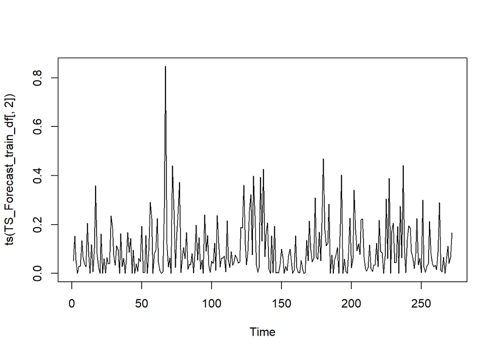

```r
plot.ts(ts(TS_Forecast_train_df[,2]))
```

```r
auto.arima(ts(TS_Forecast_train_df[,2]))
```

```
## Series: ts(TS_Forecast_train_df[, 2])
## ARIMA(2,0,2) with non-zero mean
##
## Coefficients:
##          ar1      ar2      ma1     ma2    mean
##       0.3694  -0.8694  -0.2703  0.8494  0.1001
## s.e.  0.1214   0.0754   0.1280  0.0814  0.0069
##
## sigma^2 = 0.01204:  log likelihood = 217.54
## AIC=-423.07   AICc=-422.76   BIC=-401.44
```

```
## <><><><><><><><><><><><><><>
##
## Coefficients:
##       Estimate     SE  t.value p.value
## ar1     0.3768 0.1241   3.0362  0.0026
## ar2    -0.8711 0.0787 -11.0626  0.0000
## ma1    -0.2798 0.1353  -2.0683  0.0396
## ma2     0.8489 0.0793  10.7013  0.0000
## sar1   -0.0729 0.0638  -1.1430  0.2541
## xmean   0.1005 0.0065  15.3993  0.0000
##
## sigma^2 estimated as 0.01174804 on 266 degrees of freedom
##
## AIC = -1.552844  AICc = -1.551679  BIC = -1.460048
##
```

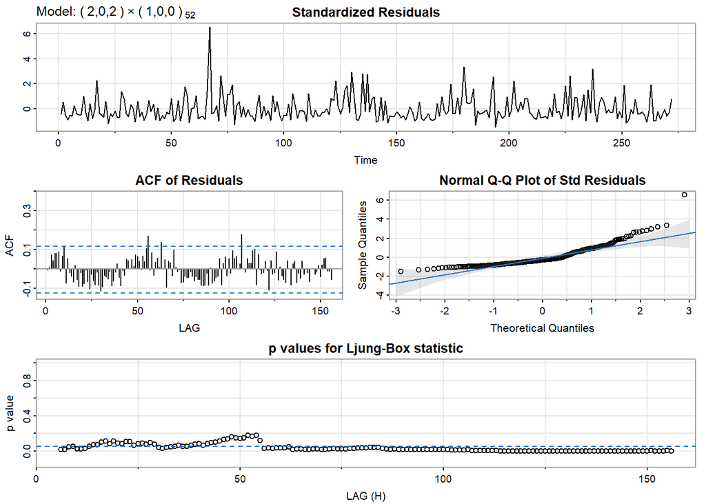

```r
sarima(ts(TS_Forecast_train_df[,2]),2,0,2,1,0,0,S=52)
```

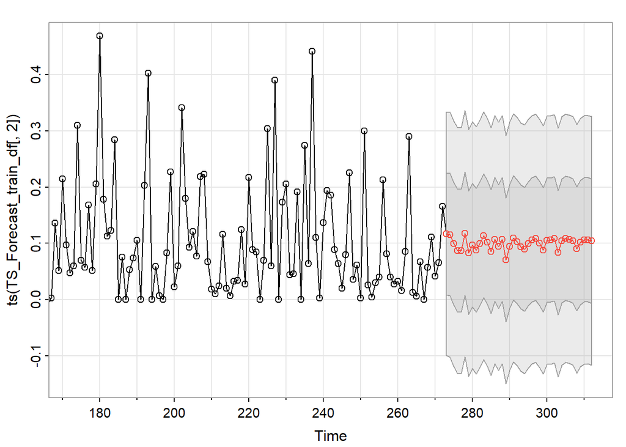

```r
PRCP.sarima.S = sarima.for(ts(TS_Forecast_train_df[,2]),40,2,0,2,1,0,0,S=52)
```

TMIN.mean

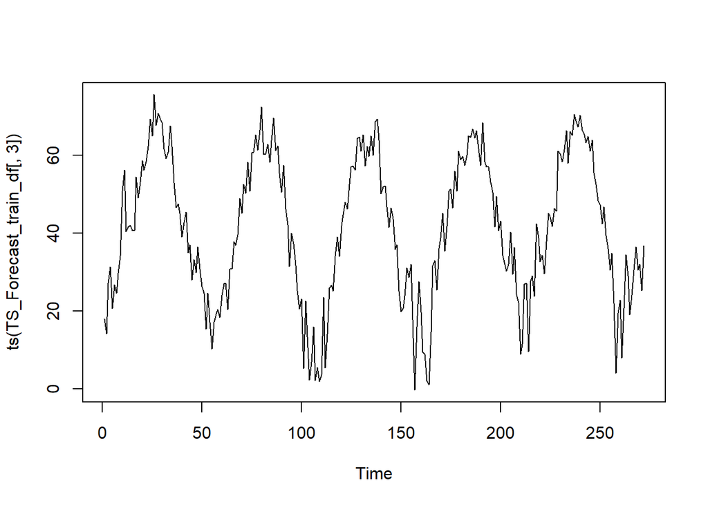

```r
plot.ts(ts(TS_Forecast_train_df[,3]))
```

```r
auto.arima(ts(TS_Forecast_train_df[,3]))
```

```
## Series: ts(TS_Forecast_train_df[, 3])
## ARIMA(1,0,1) with non-zero mean
##
## Coefficients:
##          ar1      ma1     mean
##       0.9527  -0.2273  39.3986
## s.e.  0.0192   0.0621   6.6156
##
## sigma^2 = 51.1:  log likelihood = -920.42
## AIC=1848.83   AICc=1848.98   BIC=1863.25
```

```
## <><><><><><><><><><><><><><>
##
## Coefficients:
##       Estimate     SE t.value p.value
## ar1     0.9452 0.0214 44.2279  0.0000
## ma1    -0.2876 0.0675 -4.2592  0.0000
## sar1    0.2031 0.0716  2.8357  0.0049
## xmean  40.0023 6.2861  6.3637  0.0000
##
## sigma^2 estimated as 48.72046 on 268 degrees of freedom
##
## AIC = 6.775088  AICc = 6.775639  BIC = 6.841372
##
```

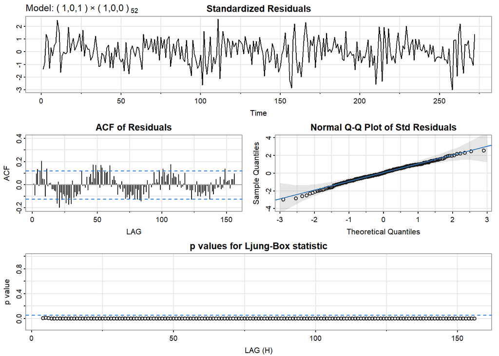

```r
sarima(ts(TS_Forecast_train_df[,3]),1,0,1,1,0,0,S=52)
```

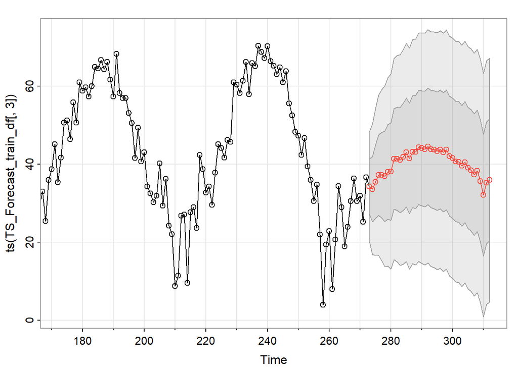

```r
TMIN.sarima.S = sarima.for(ts(TS_Forecast_train_df[,3]),40,1,0,1,1,0,0,S=52)
```

AWND.mean

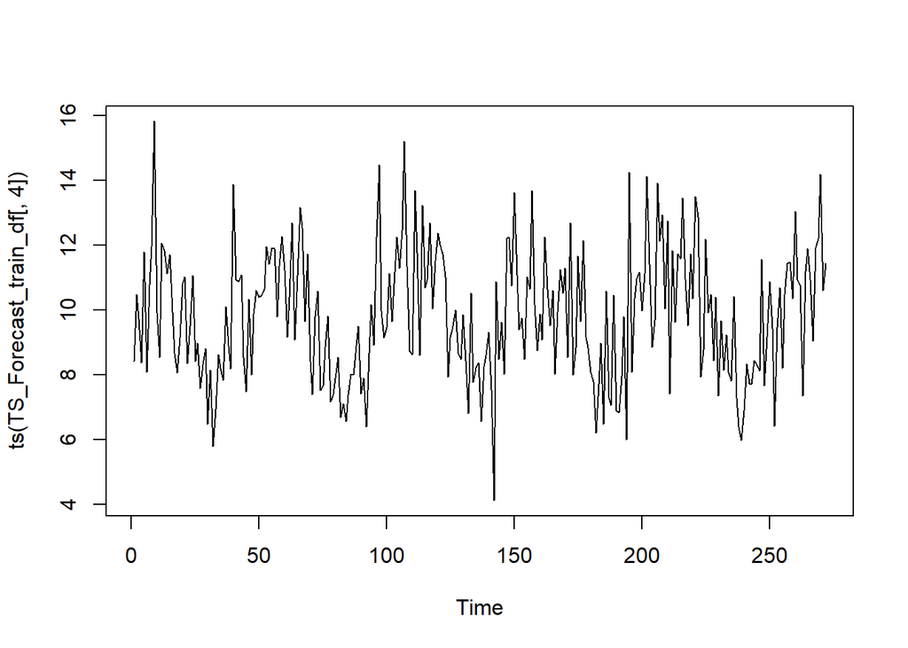

```r
plot.ts(ts(TS_Forecast_train_df[,4]))
```

```r
auto.arima(ts(TS_Forecast_train_df[,4]))
```

```
## Series: ts(TS_Forecast_train_df[, 4])
## ARIMA(1,0,1) with non-zero mean
##
## Coefficients:
##          ar1      ma1    mean
##       0.8983  -0.6688  9.8604
## s.e.  0.0395   0.0607  0.3387
##
## sigma^2 = 3.112:  log likelihood = -539.06
## AIC=1086.12   AICc=1086.27   BIC=1100.54
```

```
## <><><><><><><><><><><><><><>
##
## Coefficients:
##       Estimate     SE  t.value p.value
## ar1     0.8915 0.0442  20.1479  0.0000
## ma1    -0.6963 0.0653 -10.6702  0.0000
## sar1    0.1793 0.0697   2.5747  0.0106
## xmean   9.8364 0.3372  29.1721  0.0000
##
## sigma^2 estimated as 2.987152 on 268 degrees of freedom
##
## AIC = 3.976347  AICc = 3.976898  BIC = 4.04263
##
```

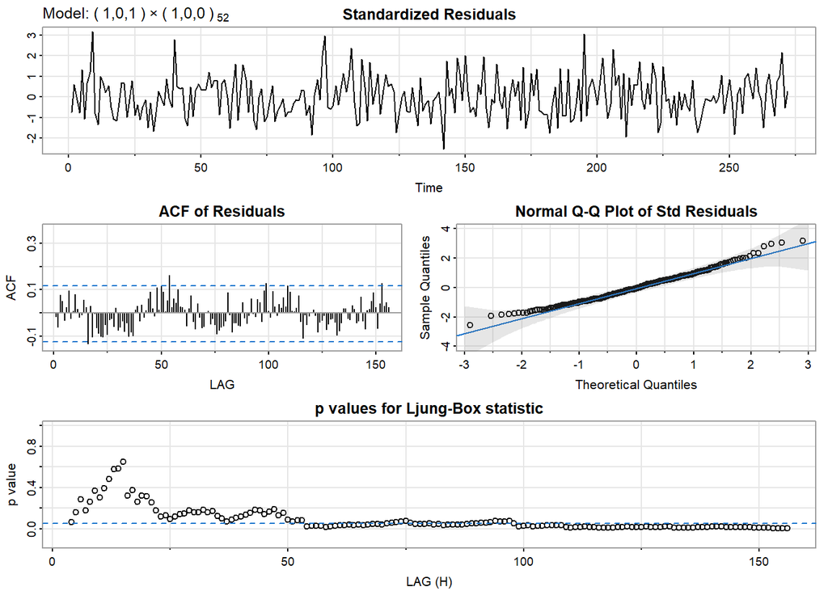

```r
sarima(ts(TS_Forecast_train_df[,4]),1,0,1,1,0,0,S=52)
```

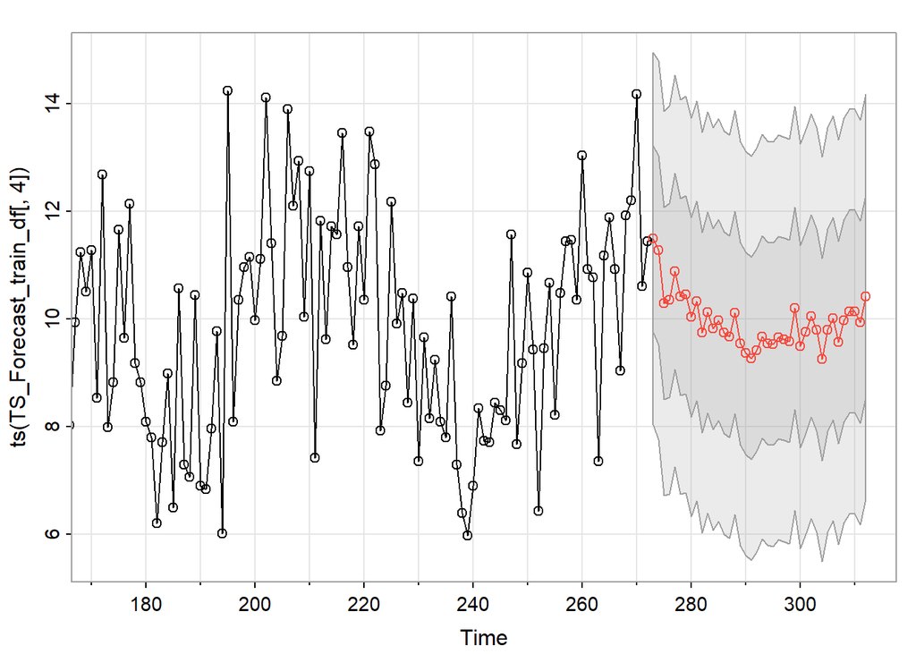

```r
AWND.sarima.S = sarima.for(ts(TS_Forecast_train_df[,4]),40,1,0,1,1,0,0,S=52)
```

SNOW.mean

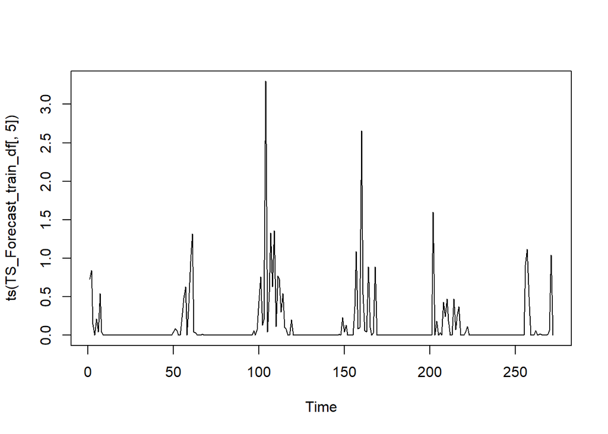

```r
plot.ts(ts(TS_Forecast_train_df[,5]))
```

```r
auto.arima(ts(TS_Forecast_train_df[,5]))
```

```
## Series: ts(TS_Forecast_train_df[, 5])
## ARIMA(1,0,3) with non-zero mean
##
## Coefficients:
##          ar1      ma1      ma2     ma3    mean
##       0.7482  -0.6249  -0.0311  0.2352  0.1327
## s.e.  0.0932   0.1057   0.0734  0.0627  0.0458
##
## sigma^2 = 0.112:  log likelihood = -85.88
## AIC=183.77   AICc=184.08   BIC=205.4
```

```
## <><><><><><><><><><><><><><>
##
## Coefficients:
##       Estimate     SE t.value p.value
## ar1     0.7512 0.0923  8.1434  0.0000
## ma1    -0.6263 0.1042 -6.0084  0.0000
## ma2    -0.0309 0.0732 -0.4222  0.6732
## ma3     0.2360 0.0625  3.7754  0.0002
## sar1   -0.0150 0.0618 -0.2430  0.8082
## xmean   0.1331 0.0458  2.9069  0.0040
##
## sigma^2 estimated as 0.1098805 on 266 degrees of freedom
##
## AIC = 0.6827495  AICc = 0.6839149  BIC = 0.7755459
##
```

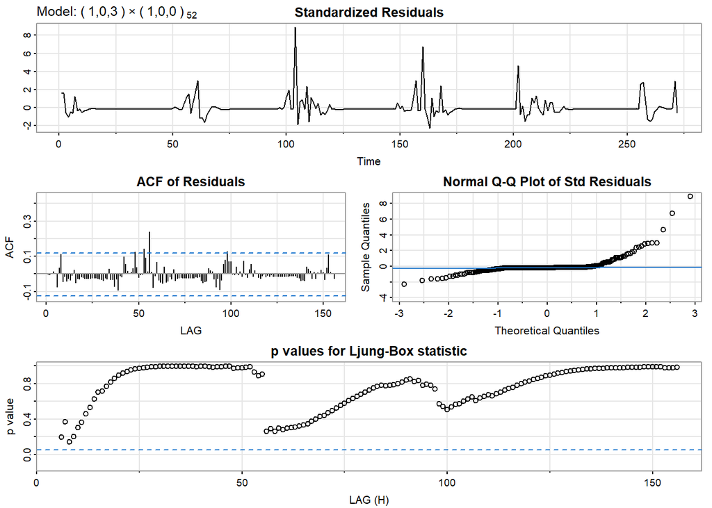

```r
sarima(ts(TS_Forecast_train_df[,5]),1,0,3,1,0,0,S=52)
```

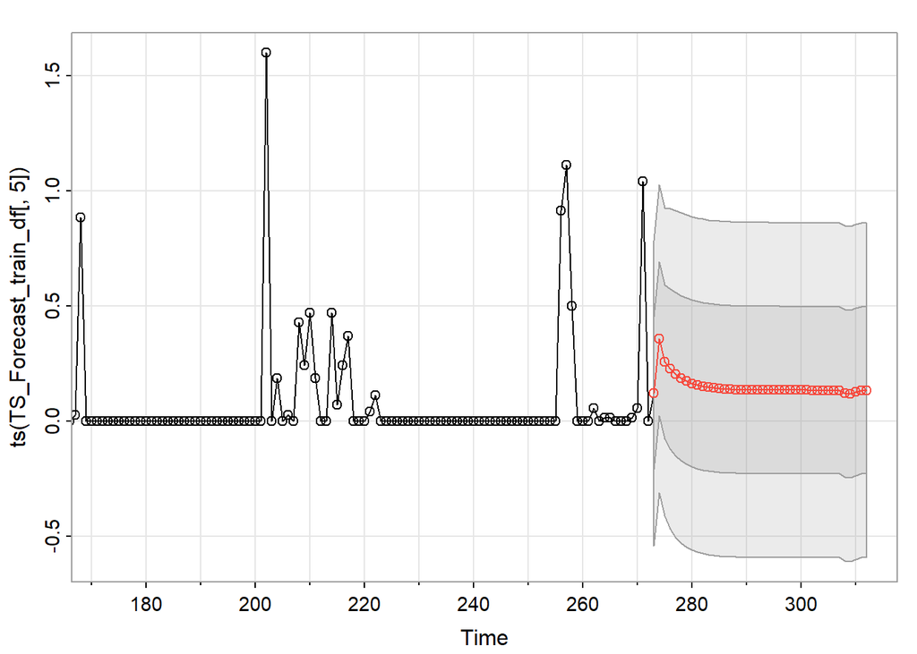

```r
SNOW.sarima.S = sarima.for(ts(TS_Forecast_train_df[,5]),40,1,0,3,1,0,0,S=52)
```

SNWD.mean

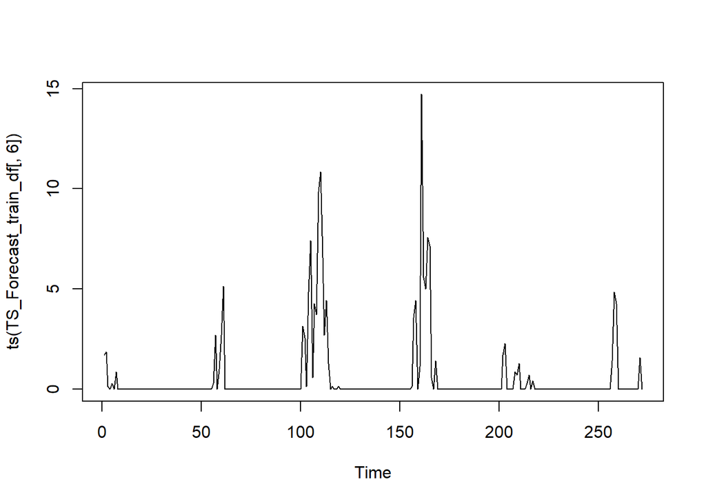

```r
plot.ts(ts(TS_Forecast_train_df[,6]))
```

```r
auto.arima(ts(TS_Forecast_train_df[,6]))
```

```
## Series: ts(TS_Forecast_train_df[, 6])
## ARIMA(1,0,5) with non-zero mean
##
## Coefficients:
##          ar1      ma1      ma2     ma3     ma4      ma5    mean
##       0.7760  -0.2090  -0.1914  0.1831  0.1946  -0.1862  0.5648
## s.e.  0.1147   0.1305   0.0843  0.0611  0.0747   0.0842  0.2739
##
## sigma^2 = 1.719:  log likelihood = -456.59
## AIC=929.18   AICc=929.73   BIC=958.03
```

```
## <><><><><><><><><><><><><><>
##
## Coefficients:
##       Estimate     SE t.value p.value
## ar1     0.7843 0.1151  6.8128  0.0000
## ma1    -0.2381 0.1302 -1.8289  0.0685
## ma2    -0.2405 0.0853 -2.8200  0.0052
## ma3     0.2179 0.0605  3.6000  0.0004
## ma4     0.1487 0.0790  1.8815  0.0610
## ma5    -0.1723 0.0818 -2.1068  0.0361
## sar1    0.2029 0.0599  3.3878  0.0008
## xmean   0.5341 0.3014  1.7720  0.0775
##
## sigma^2 estimated as 1.59634 on 264 degrees of freedom
##
## AIC = 3.383061  AICc = 3.385074  BIC = 3.502371
##
```

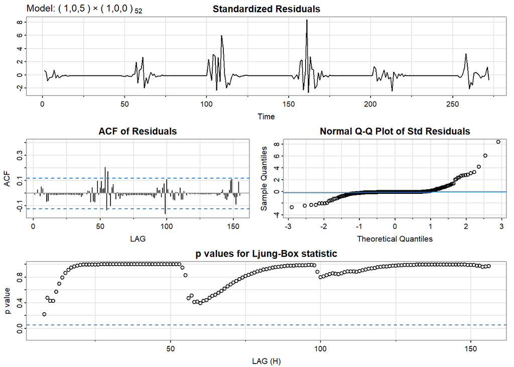

```r
sarima(ts(TS_Forecast_train_df[,6]),1,0,5,1,0,0,S=52)
```

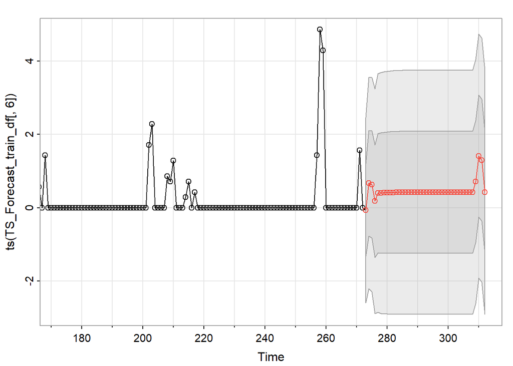

```r
SNWD.sarima.S = sarima.for(ts(TS_Forecast_train_df[,6]),40,1,0,5,1,0,0,S=52)
```

New data for forecasting

```r
names(ApothicUnit_train)
```

```
##  [1] "apothicPremiumUnit" "PRCP.mean"          "TMIN.mean"
##  [4] "AWND.mean"          "SNOW.mean"          "SNWD.mean"
##  [7] "Year"               "Month"              "WeekOfYear"
## [10] "WeekNo"             "week.end"           "week.start"
## [13] "Christmas"          "ThanksgivingDay"    "NewYearsDay"
## [16] "IndependenceDay"    "LaborDay"           "MemorialDay"
## [19] "PresidentsDay"      "MLKingsBirthday"    "VeteransDay"
```

```r
names(ApothicUnit_test)
```

```
##  [1] "apothicPremiumUnit" "PRCP.mean"          "TMIN.mean"
##  [4] "AWND.mean"          "SNOW.mean"          "SNWD.mean"
##  [7] "Year"               "Month"              "WeekOfYear"
## [10] "WeekNo"             "week.end"           "week.start"
## [13] "Christmas"          "ThanksgivingDay"    "NewYearsDay"
## [16] "IndependenceDay"    "LaborDay"           "MemorialDay"
## [19] "PresidentsDay"      "MLKingsBirthday"    "VeteransDay"
```

```r
newxreg = data.frame(PRCP.mean = PRCP.sarima.S$pred,
                     TMIN.mean=TMIN.sarima.S$pred,
                     AWND.mean=AWND.sarima.S$pred,
                     SNOW.mean=SNOW.sarima.S$pred,
                     SNWD.mean=SNWD.sarima.S$pred,
                     Christmas=ApothicUnit_test$Christmas,
                     NewYearsDay=ApothicUnit_test$NewYearsDay,
                     IndependenceDay=ApothicUnit_test$IndependenceDay,
                     LaborDay=ApothicUnit_test$LaborDay,
                     ThanksgivingDay=ApothicUnit_test$ThanksgivingDay,
                     MemorialDay=ApothicUnit_test$MemorialDay,
                     PresidentsDay=ApothicUnit_test$PresidentsDay,
                     MLKingsBirthday=ApothicUnit_test$MLKingsBirthday,
                     VeteransDay=ApothicUnit_test$VeteransDay,
                     WeekOfYear = ApothicUnit_test$WeekOfYear,
                     WeekNo=ApothicUnit_test$WeekNo,
                     Month=as.factor(ApothicUnit_test$Month),
                     Year=ApothicUnit_test$Year)
newxreg = newxreg %>%
  dplyr::mutate(SNOW.Binary = ifelse(newxreg$SNOW.mean>=0.2,1,0),
                SNWD.Binary = ifelse(newxreg$SNWD.mean>=2,1,0)) %>%
  dplyr::mutate(SNOW.Binary.Back1 = c(SNOW.Binary[-1],0),
                SNWD.Binary.Back1 = c(SNWD.Binary[-1],0)) %>%
  as.data.frame()
```

str(newxreg)

##### 8.1.2.2 Five weather variables as exogenous

Model

```
## <><><><><><><><><><><><><><>
##
## Coefficients:
##           Estimate       SE t.value p.value
## ma1        -0.4736   0.0616 -7.6842  0.0000
## ma2        -0.1804   0.0675 -2.6710  0.0080
## sar1        0.5451   0.0542 10.0587  0.0000
## PRCP.mean 136.6078 265.6846  0.5142  0.6076
## TMIN.mean -10.3337   5.3204 -1.9423  0.0532
## AWND.mean  23.1834  19.2006  1.2074  0.2284
## SNOW.mean -14.2153  88.6499 -0.1604  0.8727
## SNWD.mean  17.4670  25.9689  0.6726  0.5018
##
## sigma^2 estimated as 333113.1 on 263 degrees of freedom
##
## AIC = 15.68993  AICc = 15.69196  BIC = 15.80956
##
```

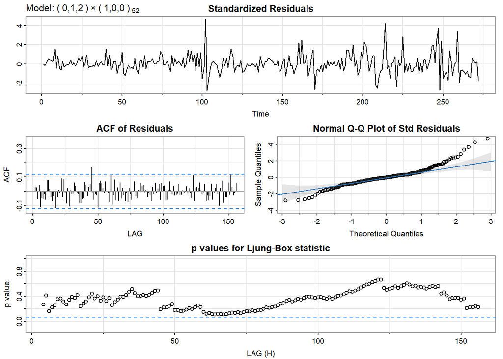

```r
sarima_model3_exo = sarima(ts(TS_Forecast_train_df[,1]),0,1,2,1,0,0,S=52,
                       xreg=TS_Forecast_train_df[,2:6])
```

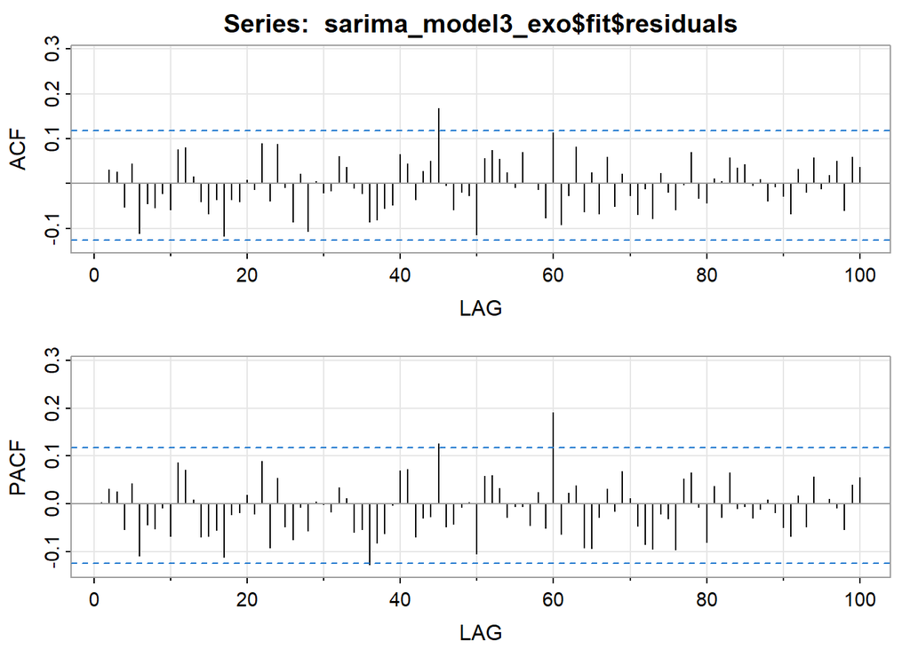

```
##      [,1] [,2] [,3]  [,4] [,5]  [,6]  [,7]  [,8]  [,9] [,10] [,11] [,12] [,13]
## ACF     0 0.03 0.03 -0.05 0.04 -0.11 -0.05 -0.05 -0.02 -0.06  0.08  0.08  0.02
## PACF    0 0.03 0.03 -0.05 0.04 -0.11 -0.04 -0.05 -0.01 -0.07  0.09  0.07  0.01
##      [,14] [,15] [,16] [,17] [,18] [,19] [,20] [,21] [,22] [,23] [,24] [,25]
## ACF  -0.04 -0.07 -0.04 -0.12 -0.04 -0.04  0.01 -0.01  0.09 -0.04  0.09 -0.01
## PACF -0.07 -0.07 -0.05 -0.11 -0.02 -0.02  0.02 -0.02  0.09 -0.09  0.05 -0.05
##      [,26] [,27] [,28] [,29] [,30] [,31] [,32] [,33] [,34] [,35] [,36] [,37]
## ACF  -0.09  0.02 -0.11  0.01 -0.02 -0.02  0.06  0.04 -0.01 -0.02 -0.08 -0.08
## PACF -0.07 -0.01 -0.06  0.00  0.00 -0.02  0.03  0.01 -0.06 -0.05 -0.13 -0.08
##      [,38] [,39] [,40] [,41] [,42] [,43] [,44] [,45] [,46] [,47] [,48] [,49]
## ACF  -0.05 -0.05  0.06  0.04 -0.04  0.03  0.05  0.17  0.00 -0.06 -0.02 -0.03
## PACF -0.06  0.00  0.07  0.07 -0.07 -0.03 -0.03  0.13 -0.05 -0.04 -0.01  0.00
##      [,50] [,51] [,52] [,53] [,54] [,55] [,56] [,57] [,58] [,59] [,60] [,61]
## ACF  -0.11  0.06  0.08  0.05  0.02 -0.01  0.07  0.00 -0.01 -0.08  0.11 -0.09
## PACF -0.10  0.06  0.06  0.03 -0.03 -0.01 -0.01 -0.05  0.02 -0.05  0.19 -0.06
##      [,62] [,63] [,64] [,65] [,66] [,67] [,68] [,69] [,70] [,71] [,72] [,73]
## ACF  -0.03  0.08 -0.06  0.03 -0.07  0.06 -0.05  0.02 -0.03 -0.07 -0.01 -0.08
## PACF  0.02  0.04 -0.09 -0.09 -0.03  0.03 -0.02  0.07  0.01 -0.05 -0.08 -0.09
##      [,74] [,75] [,76] [,77] [,78] [,79] [,80] [,81] [,82] [,83] [,84] [,85]
## ACF   0.02 -0.02 -0.06  0.00  0.07 -0.03 -0.04  0.01  0.00  0.06  0.04  0.04
## PACF -0.02 -0.03 -0.10  0.05  0.06 -0.01 -0.08  0.04 -0.03  0.07 -0.01  0.00
##      [,86] [,87] [,88] [,89] [,90] [,91] [,92] [,93] [,94] [,95] [,96] [,97]
## ACF   0.00  0.01 -0.04 -0.01 -0.03 -0.07  0.03 -0.02  0.06 -0.01  0.02  0.05
## PACF -0.03 -0.01  0.01 -0.02 -0.05 -0.07  0.02 -0.05  0.06  0.00  0.01 -0.01
##      [,98] [,99] [,100]
## ACF  -0.06  0.06   0.04
## PACF -0.05  0.04   0.06
```

```r
acf2(sarima_model3_exo$fit$residuals,max.lag=100)
```

```r
auto.arima(sarima_model3_exo$fit$residuals)
```

```
## Series: sarima_model3_exo$fit$residuals
## ARIMA(0,0,0) with zero mean
##
## sigma^2 = 331888:  log likelihood = -2114.86
## AIC=4231.72   AICc=4231.73   BIC=4235.32
```

Prediction

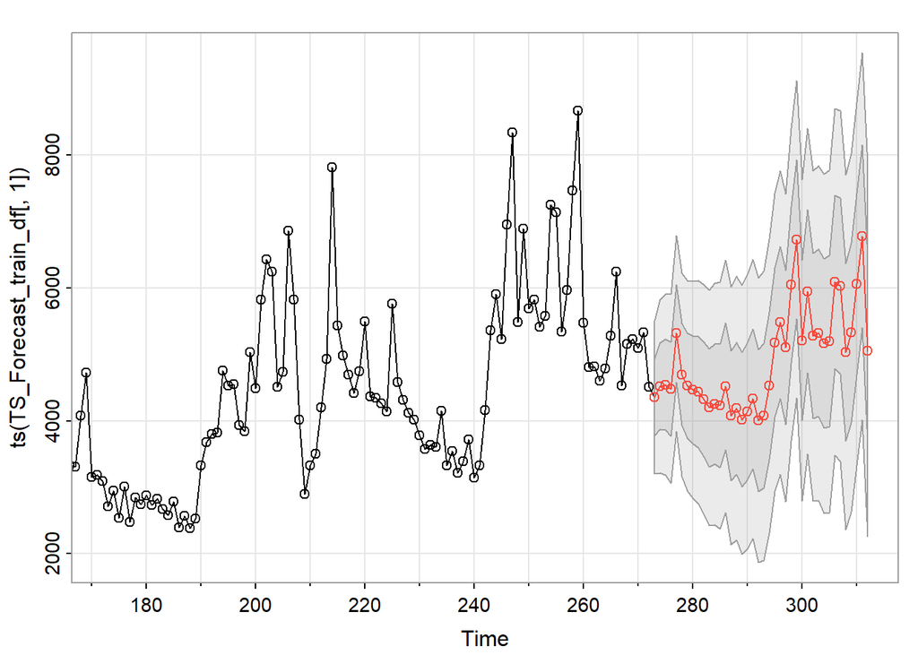

```r
sarima_model3_exo_pred = sarima.for(ts(TS_Forecast_train_df[,1]),40,0,1,2,1,0,0,S=52,
                                xreg=TS_Forecast_train_df[,2:6],
                                newxreg=newxreg[,1:5])
```

```r
Metrics.fun(sarima_model3_exo_pred$pred,TS_Forecast_test_df[,1])
```

```
##        MAE     RMSE
## 1 581.9214 709.9742
```

### 8.2 bsts (Bayesian Structural Time Series) models

#### 8.2.1 Local level model with S=52

```r
ss = AddLocalLevel(list(),TS_Forecast_train_df[,1])
ss = AddSeasonal(ss,TS_Forecast_train_df[,1],nseasons=52)
bsts.Local.Level = bsts(TS_Forecast_train_df[,1],
                        state.specification=ss,niter=1000)
```

[output not shown]

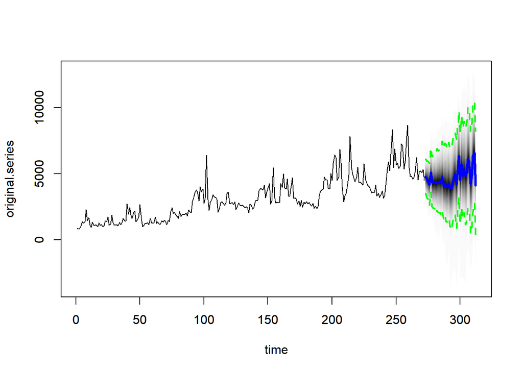

```r
bsts.Local.Level.Pred = predict(bsts.Local.Level,horizon=40,burn=200)
plot(bsts.Local.Level.Pred)
```

```r
Metrics.fun(bsts.Local.Level.Pred$mean,TS_Forecast_test_df[,1])
```

```
##        MAE     RMSE
## 1 667.1934 772.9176
```